# Proyecto Final - Parte 5: Estimación del Valor en Riesgo

Portafolio de seis emisoras de la BMV: Banorte, Bimbo, Walmex, América Móvil, Volaris y BanBajío

Jeronimo Rojas Alvarado (731609), Alan Jesús Hernández Soto (752714), Francisco Josué Ramírez Avila (747819), JP Mendez

26/11/2026

# 1 Introducción

En las cuatro entregas anteriores (Rojas Alvarado et al., 2026) construimos el perfil de riesgo de Banco del Bajío (BanBajío). En la Parte 1 vimos que es un banco orientado al crédito empresarial cuya rentabilidad depende del ciclo de tasas de interés. En la Parte 2 mostramos que el precio de la acción responde a choques que los inversionistas no controlan, como la pandemia, el ciclo de Banxico y las elecciones de 2024. En la Parte 3 rechazamos la normalidad de los rendimientos (colas pesadas) y en la Parte 4 confirmamos que la volatilidad cambia en el tiempo y que conviene medirla con modelos dinámicos. Faltaba el último paso de la gestión de riesgos: traducir la volatilidad en una **pérdida monetaria** con una probabilidad asociada.

Esta quinta entrega estima el **Valor en Riesgo (VaR)** y el **Expected Shortfall (ES)** de un portafolio de 600 mil pesos formado por las seis emisoras que se analizan en el curso: Grupo Financiero Banorte, Grupo Bimbo, Walmart de México, América Móvil, Volaris y BanBajío, con 100 mil pesos en cada una. El propósito es responder cuánto podría perder el portafolio en uno, cinco, diez y veinte días con 95%, 97.5% y 99% de confianza, comparar una metodología no paramétrica (simulación histórica) con una paramétrica (normal), verificar ambas con *backtesting*, encontrar la composición que minimiza el VaR y estimar por Montecarlo el VaR y el ES de una posición de 100 mil pesos en BanBajío. La fecha de análisis es el 26 de noviembre de 2026.

Incorporamos la retroalimentación de la Parte 4: **ninguna evaluación de desempeño usa datos que hayan servido para estimar el modelo evaluado**. En el *backtesting*, el VaR de cada día se calcula sólo con la información disponible hasta el día anterior, y la verificación de la optimización estima los pesos antes del periodo con el que se evalúan.

El documento se organiza así. La sección 2 construye el portafolio, documenta su valor inicial y sus rendimientos. La sección 3 estima el VaR por simulación histórica con toda la información disponible y la sección 4 el VaR paramétrico con la volatilidad y las covarianzas de los últimos seis meses, incluido el escalamiento temporal. La sección 5 hace el *backtesting* de ambas metodologías, la sección 6 optimiza el portafolio y la sección 7 estima el VaR y el ES de BanBajío por Montecarlo. La sección 8 responde las preguntas de análisis y la sección 9 concluye y elige la metodología que usaríamos en la práctica. El código completo está en el anexo.

# 2 Construcción del portafolio

## 2.1 Datos y diseño del análisis

Descargamos de Yahoo Finance (2026), con el paquete `quantmod` (Ryan y Ulrich, 2026), los precios diarios de las seis emisoras (Tabla 1). Usamos el precio **ajustado** por dividendos y *splits*, como en los códigos de clase (`Ad()`; Ruiz, 2026d) y en la Parte 4. El día en que una acción empieza a cotizar sin derecho al dividendo su precio de cierre baja aproximadamente en el monto pagado, aunque el accionista no pierde porque lo recibe en efectivo. Con el precio de cierre esas caídas aparecerían como pérdidas en la simulación histórica y engrosarían artificialmente la cola izquierda; el precio ajustado elimina ese efecto.

Tabla 1. Emisoras que integran el portafolio

| Emisora | Clave en Yahoo Finance | Empresa | Sector |
| --- | --- | --- | --- |
| GFNORTE | GFNORTEO.MX | Grupo Financiero Banorte | Servicios financieros |
| BIMBO | BIMBOA.MX | Grupo Bimbo | Alimentos |
| WALMEX | WALMEX.MX | Walmart de México | Comercio minorista |
| AMX | AMXB.MX | América Móvil | Telecomunicaciones |
| VOLAR | VOLARA.MX | Volaris (Controladora Vuela) | Transporte aéreo |
| BBAJIO | BBAJIOO.MX | Banco del Bajío | Servicios financieros |

Para que cada escenario histórico sea un movimiento **conjunto** de las seis emisoras, conservamos sólo las fechas en que cotizan todas (no se mezclan rendimientos de días distintos; Ruiz, 2026c). La muestra va del 2 de enero de 2019 al 26 de noviembre de 2026, con 1,987 rendimientos diarios. La Tabla 2 resume las decisiones de diseño y su justificación, y la Tabla 3 documenta la alineación de los datos.

Tabla 2. Diseño del análisis y justificación de cada decisión

| Elemento | Valor | Justificación estadística | Justificación financiera |
| --- | --- | --- | --- |
| Fecha de análisis | 26 de noviembre de 2026 | Último cierre común de las seis emisoras | El VaR mide el riesgo de la posición vigente hoy |
| Muestra de la simulación histórica | 2 de enero de 2019 a 26 de noviembre de 2026 (1,987 escenarios) | Con T escenarios, el 1% extremo contiene cerca de T/100 observaciones; más datos dan un cuantil más estable | Incluye un ciclo completo: COVID-19, alzas de Banxico, elecciones de 2024 y aranceles de 2025; es la ventana del código de clase |
| Precio | Ajustado por dividendos y splits | Evita rendimientos espurios en fechas ex-dividendo | El accionista recibe el dividendo: no es una pérdida |
| Rendimiento y revaluación | Logarítmico diario; revaluación completa con S0·exp(r) | Los rendimientos logarítmicos se suman en el tiempo; la revaluación completa no usa aproximaciones | El P&L se calcula revaluando la posición de hoy |
| Posición | 100,000 pesos por emisora (600,000 en total) | Pesos iguales de 1/6 | Indicación de la consigna; ninguna emisora domina el portafolio |
| Niveles de confianza | 95%, 97.5% y 99% | Cuantiles de 5%, 2.5% y 1% de la cola izquierda | 99%: referencia de Basilea; 97.5%: nivel del ES en el marco regulatorio actual |
| Horizontes | 1, 5, 10 y 20 días hábiles | Escenarios históricos de h días traslapados y regla de la raíz en el paramétrico | Una semana, dos semanas (horizonte regulatorio) y un mes |
| Volatilidad y covarianzas del VaR paramétrico | Últimos seis meses de rendimientos diarios | Misma ventana para volatilidades y covarianzas | Indicación de la consigna; refleja el régimen reciente del mercado |
| Backtesting | 500 días de prueba; VaR con información hasta el día anterior | Evaluación fuera de muestra con pruebas de Kupiec y Christoffersen | Ventana del código de clase; con 500 días se esperan 5 violaciones al 99% |
| Optimización | Varianza mínima sin ventas en corto (solve.QP) | Con media cercana a cero, minimizar el VaR equivale a minimizar w’Σw | Restricción realista: el inversionista no vende en corto |
| Montecarlo (VaR individual) | GBM con 10,000 simulaciones y semilla 123 | El intervalo de confianza del cuantil mide el error de simulación | Mismos datos que la simulación histórica, para aislar el efecto del supuesto normal |

Tabla 3. Alineación de los datos y rendimientos diarios extremos de cada emisora

| Emisora | Días con precio (serie propia) | Días comunes usados | Rend. mínimo (%) | Fecha del mínimo | Rend. máximo (%) | Fecha del máximo |
| --- | --- | --- | --- | --- | --- | --- |
| GFNORTE | 1,987 | 1,987 | -14.45 | 17/03/2020 | 8.65 | 09/04/2025 |
| BIMBO | 1,987 | 1,987 | -12.55 | 27/03/2020 | 13.17 | 28/07/2020 |
| WALMEX | 1,987 | 1,987 | -7.24 | 17/07/2025 | 7.53 | 13/12/2024 |
| AMX | 1,987 | 1,987 | -19.35 | 01/09/2023 | 8.11 | 09/06/2020 |
| VOLAR | 1,987 | 1,987 | -33.92 | 17/03/2020 | 13.77 | 19/12/2025 |
| BBAJIO | 1,987 | 1,987 | -11.61 | 17/09/2021 | 9.81 | 24/03/2020 |

La diferencia entre los días de cada serie y los días comunes corresponde a fechas en las que alguna otra emisora no registró precio; eliminarlas garantiza que cada escenario use los seis rendimientos del mismo día. En la muestra hay 1 rendimiento diario mayores a 20% en valor absoluto (Tabla 3). Los conservamos: son exactamente los movimientos extremos que la simulación histórica debe reproducir, y eliminarlos reduciría artificialmente el VaR.

## 2.2 Valor inicial del portafolio

El portafolio invierte 100 mil pesos en cada emisora al precio de cierre de la fecha de análisis, $S_{j,0}$. El número de acciones y el valor inicial son

$$n_j=\frac{100{,}000}{S_{j,0}},\qquad
V_0=\sum_{j=1}^{6}n_j\,S_{j,0}=n^{\top}S_0,\qquad
w_j=\frac{n_j\,S_{j,0}}{V_0}=\frac{1}{6}.$$

Tabla 4. Valor inicial del portafolio al 26 de noviembre de 2026

| Emisora | Precio al cierre (MXN) | Número de acciones | Inversión (MXN) | Peso (%) |
| --- | --- | --- | --- | --- |
| GFNORTE | 203.11 | 492.34 | 100,000 | 16.67 |
| BIMBO | 71.78 | 1,393.15 | 100,000 | 16.67 |
| WALMEX | 53.95 | 1,853.57 | 100,000 | 16.67 |
| AMX | 24.29 | 4,116.92 | 100,000 | 16.67 |
| VOLAR | 16.12 | 6,203.47 | 100,000 | 16.67 |
| BBAJIO | 55.79 | 1,792.44 | 100,000 | 16.67 |
| Total | — | — | 600,000 | 100.00 |

El valor inicial del portafolio es **V<sub>0</sub> = $600,000** al 26 de noviembre de 2026 (Tabla 4). Trabajamos con fracciones de acción para que cada posición valga exactamente 100 mil pesos; si se compraran sólo acciones enteras el valor sería de $599,835, una diferencia de $165 (0.028%) sin efecto relevante sobre el riesgo.

La rúbrica menciona un portafolio con 100 acciones de cada activo, como el ejemplo del código de clase, mientras que la consigna pide 100 mil pesos por activo y un valor total de 600 mil. Seguimos la consigna, porque con 100 acciones de cada emisora el portafolio valdría $42,504 y quedaría concentrado: GFNORTE pesaría 47.8% y VOLAR sólo 3.8%, de modo que el riesgo dependería sobre todo del precio por acción y no de una decisión de inversión (Tabla 5).

Tabla 5. Ponderaciones según la definición del portafolio

| Emisora | Peso con 100 mil pesos por emisora (%) | Peso con 100 acciones por emisora (%) |
| --- | --- | --- |
| GFNORTE | 16.67 | 47.79 |
| BIMBO | 16.67 | 16.89 |
| WALMEX | 16.67 | 12.69 |
| AMX | 16.67 | 5.71 |
| VOLAR | 16.67 | 3.79 |
| BBAJIO | 16.67 | 13.13 |

## 2.3 Rendimientos del portafolio

Para cada emisora calculamos el rendimiento logarítmico diario $r_{j,t}=\ln\left(S_{j,t}/S_{j,t-1}\right)$. El rendimiento del portafolio en la fecha $t$ es el que tendría **la composición de hoy** si se repitieran los rendimientos de ese día:

$$R_{p,t}=\sum_{j=1}^{6}w_j\left(e^{r_{j,t}}-1\right)=\frac{P\&L_t}{V_0},\qquad
r_{p,t}=\ln\left(1+R_{p,t}\right).$$

Es exactamente la cantidad que revalúa la simulación histórica de la sección 3, por lo que los rendimientos del portafolio y su distribución de pérdidas y ganancias son la misma información en distinta escala. La Tabla 6 resume los rendimientos de cada emisora y del portafolio, y la Tabla 7 sus correlaciones.

Tabla 6. Estadísticas de los rendimientos logarítmicos diarios (toda la muestra)

| Serie | Media diaria (%) | Desv. diaria (%) | Vol. anual (%) | Asimetría | Curtosis | Mínimo (%) | Máximo (%) |
| --- | --- | --- | --- | --- | --- | --- | --- |
| GFNORTE | 0.0640 | 2.153 | 34.19 | -0.322 | 6.15 | -14.45 | 8.65 |
| BIMBO | 0.0368 | 2.007 | 31.86 | 0.219 | 6.66 | -12.55 | 13.17 |
| WALMEX | 0.0150 | 1.622 | 25.74 | 0.061 | 4.31 | -7.24 | 7.53 |
| AMX | 0.0399 | 1.580 | 25.08 | -1.140 | 21.20 | -19.35 | 8.11 |
| VOLAR | 0.0217 | 3.130 | 49.69 | -0.871 | 12.93 | -33.92 | 13.77 |
| BBAJIO | 0.0508 | 2.041 | 32.40 | -0.239 | 6.08 | -11.61 | 9.81 |
| Portafolio (pesos iguales) | 0.0536 | 1.220 | 19.37 | -0.495 | 6.94 | -9.54 | 4.70 |

Tabla 7. Matriz de correlaciones de los rendimientos diarios (toda la muestra)

| Emisora | GFNORTE | BIMBO | WALMEX | AMX | VOLAR | BBAJIO |
| --- | --- | --- | --- | --- | --- | --- |
| GFNORTE | 1.00 | 0.27 | 0.29 | 0.15 | 0.29 | 0.42 |
| BIMBO | 0.27 | 1.00 | 0.21 | 0.07 | 0.14 | 0.20 |
| WALMEX | 0.29 | 0.21 | 1.00 | 0.13 | 0.16 | 0.21 |
| AMX | 0.15 | 0.07 | 0.13 | 1.00 | 0.09 | 0.11 |
| VOLAR | 0.29 | 0.14 | 0.16 | 0.09 | 1.00 | 0.21 |
| BBAJIO | 0.42 | 0.20 | 0.21 | 0.11 | 0.21 | 1.00 |

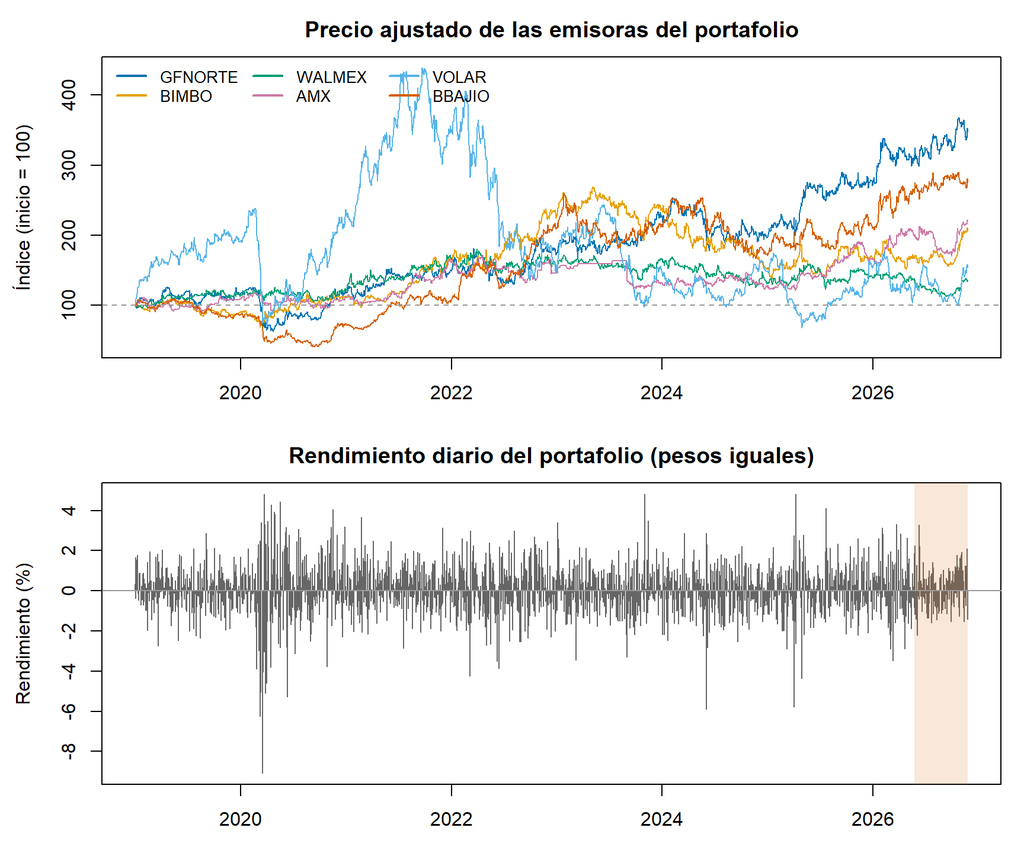

Figura 1. Arriba: precio ajustado de las seis emisoras (inicio de la muestra = 100). Abajo: rendimiento diario del portafolio con la composición actual; la zona sombreada son los últimos seis meses, que usa el VaR paramétrico.

La volatilidad anual del portafolio es de 19.37%, frente a un promedio de 33.16% de las emisoras individuales (Tabla 6): ésa es la diversificación en acción. La correlación promedio entre pares es de 0.20; la más alta es la de GFNORTE con BBAJIO (0.42) y la más baja la de BIMBO con AMX (0.07). Con correlaciones bajas, los días malos de una emisora no coinciden siempre con los de las demás. La emisora más volátil es VOLAR (49.69% anual) y la menos volátil AMX (25.08%). 6 de las seis emisoras tienen curtosis mayor que 3, el valor de una normal, y el portafolio también (6.94): los días extremos son más frecuentes de lo que supone el modelo normal, el mismo hallazgo de la Parte 3 para BanBajío. Este dato anticipa la diferencia central entre las dos metodologías de VaR.

# 3 VaR no paramétrico: simulación histórica

## 3.1 Metodología

La simulación histórica no supone ninguna distribución. Toma cada día de la muestra como un escenario conjunto y pregunta qué le pasaría **al portafolio de hoy** si se repitieran los rendimientos de esa fecha (Ruiz, 2026c; Jorion, 2007). Para el escenario $t$:

$$S_{j,1}^{(t)}=S_{j,0}\,e^{r_{j,t}},\qquad
V_1^{(t)}=\sum_{j=1}^{6}n_j\,S_{j,1}^{(t)},\qquad
P\&L^{(t)}=V_1^{(t)}-V_0 .$$

Con los 1,987 escenarios obtenemos la distribución empírica de pérdidas y ganancias. El VaR es el cuantil de su cola izquierda y se reporta como pérdida positiva; el ES es la pérdida promedio cuando se rebasa el VaR (Ruiz, 2026a):

$$VaR_{c}=-Q_{1-c}\left(P\&L\right),\qquad
ES_{c}=-E\left[P\&L\mid P\&L<-VaR_{c}\right].$$

Cada escenario aplica los seis rendimientos del mismo día, de modo que la dependencia entre emisoras queda incorporada en los movimientos conjuntos observados sin estimar una matriz de covarianzas. Usamos **toda la información disponible**, como pide la consigna: los 1,987 días desde el 2 de enero de 2019. Para el cuantil usamos la convención por defecto de R (`quantile`, tipo 7: interpolación lineal entre estadísticos de orden; Hyndman y Fan, 1996), la misma del código de clase.

## 3.2 VaR y ES a un día

Tabla 8. VaR y ES a un día por simulación histórica (portafolio de 600 mil pesos)

| Nivel de confianza | VaR (MXN) | VaR (% de V0) | ES (MXN) | ES (% de V0) | ES / VaR | Escenarios más allá del VaR |
| --- | --- | --- | --- | --- | --- | --- |
| 95% | 10,607 | 1.77 | 16,268 | 2.71 | 1.53 | 100 |
| 97.5% | 13,322 | 2.22 | 20,661 | 3.44 | 1.55 | 50 |
| 99% | 19,022 | 3.17 | 27,809 | 4.63 | 1.46 | 20 |

Con 99% de confianza, la pérdida del portafolio en un día no debería superar **$19,022** (3.17% de V<sub>0</sub>); al 95% el umbral es de $10,607 (1.77%) y al 97.5% de $13,322 (Tabla 8). El VaR no es la pérdida máxima: en 20 de los 1,987 escenarios la pérdida fue mayor que el VaR al 99%, y en esos días la pérdida promedio, el ES al 99%, fue de $27,809, 1.46 veces el VaR. Reportamos el ES porque, a diferencia del VaR, mide la magnitud de las pérdidas en la cola; por eso el marco regulatorio actual de Basilea lo usa al 97.5% (Basel Committee on Banking Supervision, 2019). Bajo normalidad, la razón ES/VaR al 99% sería de 1.15; aquí es mayor, lo que indica que, una vez rebasado el umbral, las pérdidas se alejan más de lo que supone una normal. La peor pérdida de la muestra fue de $54,586 (9.10%) el 17 de marzo de 2020.

## 3.3 Gráfica: distribución de pérdidas y ganancias y niveles de VaR

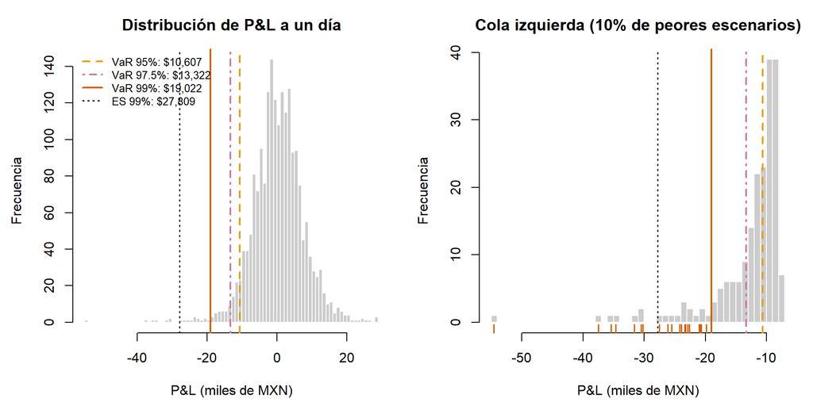

Figura 2. Distribución histórica de pérdidas y ganancias a un día del portafolio. Las líneas verticales marcan el VaR al 95%, 97.5% y 99% y el ES al 99%; el panel derecho amplía el 10% de peores escenarios y marca con rayas los que superan el VaR al 99%.

La Figura 2 muestra que la distribución de pérdidas y ganancias se concentra cerca de cero y tiene una cola izquierda larga. Cada línea vertical se lee como una probabilidad. A la derecha de la línea del 95% queda el 95% de los escenarios: en 19 de cada 20 días la pérdida no rebasaría $10,607. La línea del 97.5% deja fuera uno de cada 40 días y la del 99% uno de cada 100. Al pasar de 95% a 99% el VaR aumenta 79.3%; en una normal ese aumento sería de 41.4% (2.326/1.645). Que el aumento sea mayor confirma que la cola es más pesada que la normal: los cuantiles extremos se separan rápidamente. El panel derecho muestra que más allá del VaR al 99% todavía hay 20 escenarios dispersos; el ES (línea punteada) resume su magnitud promedio.

## 3.4 VaR a 5, 10 y 20 días

Para un horizonte de $h$ días construimos escenarios históricos de $h$ días con todas las ventanas traslapadas de la muestra y revaluamos la posición de hoy:

$$r_{j,t}^{(h)}=\sum_{k=0}^{h-1}r_{j,t-k},\qquad
P\&L^{(h,t)}=\sum_{j=1}^{6}n_j\,S_{j,0}\left(e^{r_{j,t}^{(h)}}-1\right),\qquad
VaR_{c,h}=-Q_{1-c}\left(P\&L^{(h)}\right).$$

Así el VaR de $h$ días también es un cuantil empírico: conserva las colas, la correlación entre emisoras y la dependencia temporal de la muestra, y usa toda la información disponible ($T-h+1$ escenarios). Usar $V_0$ como referencia supone que la posición no se rebalancea durante el horizonte. Las ventanas traslapadas comparten días, por lo que el cuantil de 20 días es menos preciso que el de un día; aun así es la forma estándar de usar toda la muestra sin imponer un supuesto de escalamiento. Como referencia, la Tabla 10 lo compara con la regla de la raíz aplicada al VaR histórico de un día, $VaR_{c,h}\approx VaR_{c,1}\sqrt{h}$, la misma que usa el VaR paramétrico (sección 4.3).

Tabla 9. VaR y ES por simulación histórica con escenarios de h días (V0 = 600 mil pesos)

| Horizonte (días) | Escenarios | VaR 95% (MXN) | VaR 97.5% (MXN) | VaR 99% (MXN) | VaR 99% (% de V0) | ES 97.5% (MXN) | ES 99% (MXN) |
| --- | --- | --- | --- | --- | --- | --- | --- |
| 1 | 1,987 | 10,607 | 13,322 | 19,022 | 3.17 | 20,661 | 27,809 |
| 5 | 1,983 | 23,106 | 29,901 | 37,706 | 6.28 | 43,572 | 58,987 |
| 10 | 1,978 | 32,458 | 39,134 | 57,196 | 9.53 | 62,732 | 89,684 |
| 20 | 1,968 | 43,327 | 55,084 | 93,707 | 15.62 | 94,123 | 136,597 |

Tabla 10. VaR histórico al 99%: escenarios de h días frente a la regla de la raíz

| Horizonte (días) | Escenarios de h días (MXN) | Regla de la raíz (MXN) | Diferencia (%) | VaR(h) / VaR(1) | Raíz de h |
| --- | --- | --- | --- | --- | --- |
| 1 | 19,022 | 19,022 | 0.0 | 1.00 | 1.00 |
| 5 | 37,706 | 42,534 | -11.4 | 1.98 | 2.24 |
| 10 | 57,196 | 60,153 | -4.9 | 3.01 | 3.16 |
| 20 | 93,707 | 85,069 | 10.2 | 4.93 | 4.47 |

A diez días, el VaR histórico al 99% es de **$57,196** (9.53% del portafolio) y a veinte días de $93,707 (15.62%) (Tabla 9). El riesgo crece con el horizonte, pero no linealmente: a 20 días el VaR es 4.93 veces el de un día, frente a $\sqrt{20}=4.47$ de la regla de la raíz (Tabla 10). Es decir, queda por encima de la regla de la raíz: en esta muestra las pérdidas tienden a encadenarse (días malos seguidos de días malos, el agrupamiento de volatilidad que documentamos en las Partes 3 y 4), de modo que el riesgo de varios días crece más rápido que la raíz del tiempo. La regla de la raíz es una aproximación útil, pero no un dato: depende de que los rendimientos sean independientes y de volatilidad constante.

## 3.5 Sensibilidad a la ventana y peores escenarios

Tabla 11. Sensibilidad del VaR histórico a un día a la ventana de datos

| Ventana | Desde | Escenarios | VaR 95% (MXN) | VaR 99% (MXN) | ES 99% (MXN) |
| --- | --- | --- | --- | --- | --- |
| Toda la muestra | 02/01/2019 | 1,987 | 10,607 | 19,022 | 27,809 |
| Desde 2021 (periodo de las Partes 3 y 4) | 04/01/2021 | 1,484 | 10,203 | 15,879 | 21,956 |
| Últimos 500 días (ventana del código de clase) | 27/11/2024 | 500 | 9,738 | 17,249 | 23,256 |
| Últimos 250 días (un año bursátil) | 26/11/2025 | 250 | 9,330 | 15,304 | 18,507 |

Tabla 12. Los cinco peores escenarios de la simulación histórica a un día

| Fecha | P&L (MXN) | P&L (% de V0) | Emisora con mayor caída | Su rendimiento (%) | Episodio |
| --- | --- | --- | --- | --- | --- |
| 17/03/2020 | -54,586 | -9.10 | VOLAR | -28.76 | Crisis de COVID-19 |
| 09/03/2020 | -37,456 | -6.24 | VOLAR | -10.48 | Crisis de COVID-19 |
| 03/06/2024 | -35,437 | -5.91 | GFNORTE | -11.24 | Elecciones federales de 2024 |
| 04/04/2025 | -34,653 | -5.78 | BBAJIO | -8.40 | Aranceles de EE. UU. (abril de 2025) |
| 11/06/2020 | -31,616 | -5.27 | VOLAR | -13.59 | — |

La simulación histórica sólo puede reproducir los choques que están en la ventana (Ruiz, 2026c). Con toda la muestra, el VaR al 99% es de $19,022. La ventana con el VaR más alto es “Toda la muestra” ($19,022) y la del más bajo “Últimos 250 días (un año bursátil)” ($15,304) (Tabla 11). 2 de los cinco peores escenarios provienen de la crisis de COVID-19 de 2020 (Tabla 12), un episodio que las ventanas que empiezan en 2021 no contienen. Usar toda la información disponible es, por lo tanto, una decisión de gestión de riesgos: incluye un episodio de estrés real en lugar de suponer que no volverá a ocurrir.

# 4 VaR paramétrico

## 4.1 Supuestos y estimación de parámetros

El VaR paramétrico supone que los rendimientos diarios de las seis emisoras siguen una distribución **normal conjunta**, $R\sim N_6(\mu,\Sigma)$, y que la media es despreciable en horizontes cortos ($\mu\approx 0$). Entonces la P&L del portafolio también es normal y (Ruiz, 2026b; Hull, 2018)

$$VaR_{p,c}=z_c\,V_0\,\sigma_p,\qquad
\sigma_p=\sqrt{w^{\top}\Sigma\,w},\qquad
ES_{p,c}=V_0\,\sigma_p\,\frac{\phi(z_c)}{1-c},$$

donde $z_c=\Phi^{-1}(c)$ (1.645, 1.960 y 2.326) y $\phi$ es la densidad normal estándar. La covarianza es la que incorpora la dependencia: $\sigma_p^2=\sum_j w_j^2\sigma_j^2+\sum_{i\neq j}w_iw_j\rho_{ij}\sigma_i\sigma_j$.

Siguiendo la consigna, la **volatilidad promedio diaria** de cada emisora, $\sigma_j=\sqrt{\frac{1}{n-1}\sum_t\left(r_{j,t}-\bar r_j\right)^2}$, y la **matriz de covarianzas** $\Sigma$ se estiman con los rendimientos de los últimos seis meses: del 27 de mayo de 2026 al 26 de noviembre de 2026 (129 rendimientos). Usamos la misma ventana para volatilidades y covarianzas, de modo que $\Sigma$ sea internamente consistente y refleje el régimen reciente del mercado.

Tabla 13. Volatilidad promedio diaria de los últimos seis meses frente a toda la muestra

| Emisora | Vol. diaria, 6 meses (%) | Vol. anual, 6 meses (%) | Vol. diaria, toda la muestra (%) | Cambio (%) | Media diaria, 6 meses (%) |
| --- | --- | --- | --- | --- | --- |
| GFNORTE | 1.506 | 23.91 | 2.153 | -30.0 | 0.0799 |
| BIMBO | 1.609 | 25.54 | 2.007 | -19.8 | 0.1554 |
| WALMEX | 1.376 | 21.85 | 1.622 | -15.1 | 0.0007 |
| AMX | 1.605 | 25.48 | 1.580 | 1.6 | 0.0780 |
| VOLAR | 2.836 | 45.01 | 3.130 | -9.4 | 0.1922 |
| BBAJIO | 1.339 | 21.26 | 2.041 | -34.4 | 0.0245 |

Tabla 14. Matriz de correlaciones de los últimos seis meses

| Emisora | GFNORTE | BIMBO | WALMEX | AMX | VOLAR | BBAJIO |
| --- | --- | --- | --- | --- | --- | --- |
| GFNORTE | 1.00 | 0.29 | 0.14 | 0.27 | 0.19 | 0.47 |
| BIMBO | 0.29 | 1.00 | 0.22 | 0.31 | 0.18 | 0.06 |
| WALMEX | 0.14 | 0.22 | 1.00 | 0.19 | 0.04 | 0.03 |
| AMX | 0.27 | 0.31 | 0.19 | 1.00 | 0.11 | -0.02 |
| VOLAR | 0.19 | 0.18 | 0.04 | 0.11 | 1.00 | 0.10 |
| BBAJIO | 0.47 | 0.06 | 0.03 | -0.02 | 0.10 | 1.00 |

En los últimos seis meses, 1 de las seis emisoras tuvo una volatilidad mayor que su promedio de toda la muestra (Tabla 13). La volatilidad diaria del portafolio es de 0.963% (15.29% anual), frente a 1.225% con toda la muestra: el régimen reciente es más tranquilo que el promedio histórico. La correlación promedio de los últimos seis meses es de 0.17 (Tabla 14), frente a 0.20 en toda la muestra.

## 4.2 VaR del portafolio a un día y beneficio de la diversificación

Para medir el efecto de la correlación comparamos el VaR del portafolio con la suma de los VaR de seis posiciones aisladas de 100 mil pesos, $VaR_j=z_c\,x_j\,\sigma_j$. Con correlaciones menores que uno, $VaR_p<\sum_jVaR_j$ (Ruiz, 2026b), y el VaR del portafolio también puede escribirse con la matriz de correlaciones $\rho$:

$$VaR_p=\sqrt{VaR^{\top}\rho\,VaR},\qquad
\text{Beneficio de diversificación}=\sum_j VaR_j-VaR_p .$$

Tabla 15. VaR paramétrico individual a un día y contribución de cada emisora al riesgo del portafolio

| Emisora | Inversión (MXN) | Vol. diaria (%) | VaR individual 95% (MXN) | VaR individual 99% (MXN) | Contribución al riesgo del portafolio (%) |
| --- | --- | --- | --- | --- | --- |
| GFNORTE | 100,000 | 1.506 | 2,478 | 3,505 | 17.0 |
| BIMBO | 100,000 | 1.609 | 2,647 | 3,743 | 16.5 |
| WALMEX | 100,000 | 1.376 | 2,264 | 3,202 | 9.8 |
| AMX | 100,000 | 1.605 | 2,641 | 3,735 | 14.7 |
| VOLAR | 100,000 | 2.836 | 4,664 | 6,596 | 32.1 |
| BBAJIO | 100,000 | 1.339 | 2,203 | 3,116 | 9.9 |
| Suma | 600,000 | — | 16,896 | 23,896 | 100.0 |

Tabla 16. VaR paramétrico del portafolio a un día y beneficio de la diversificación (MXN)

| Concepto | 95% | 97.5% | 99% |
| --- | --- | --- | --- |
| Suma de VaR individuales | 16,896 | 20,133 | 23,896 |
| VaR del portafolio, z·V0·raíz(w’Σw) | 9,506 | 11,327 | 13,445 |
| VaR del portafolio, raíz(VaR’ρVaR) | 9,506 | 11,327 | 13,445 |
| Beneficio de diversificación | 7,390 | 8,806 | 10,452 |
| Reducción por diversificación (%) | 43.7 | 43.7 | 43.7 |
| ES del portafolio | 11,921 | 13,511 | 15,403 |

El VaR paramétrico del portafolio a un día al 99% es de **$13,445** (2.24% de V<sub>0</sub>) y al 95% de $9,506 (Tabla 16). Las dos fórmulas del VaR del portafolio coinciden, lo que verifica el cálculo. Si las seis posiciones se administraran por separado, la suma de sus VaR al 99% sería de $23,896; al combinarlas, la correlación imperfecta reduce el riesgo en $10,452 (43.7%). La diversificación no reduce la volatilidad de ninguna emisora: el beneficio surge de que no caen todas al mismo tiempo (Ruiz, 2026b). Aunque cada emisora pesa lo mismo, no aporta lo mismo al riesgo: VOLAR explica 32.1% de la varianza del portafolio y WALMEX sólo 9.8% (Tabla 15). Esta asimetría es el punto de partida de la optimización de la sección 6.

Sobre el supuesto de media cero: la media diaria del portafolio en los últimos seis meses es de 0.088%. Incluirla, $VaR=V_0\left(z_c\sigma_p-\mu_p\right)$, cambiaría el VaR al 99% de un día a $12,914. Mantenemos $\mu\approx0$, como en la Unidad 04, porque una media estimada con seis meses es muy imprecisa. Además, como en este periodo la media es positiva, incluirla reduciría el VaR con base en rendimientos pasados que no están garantizados, de modo que el supuesto de media cero es ligeramente conservador.

## 4.3 Escalamiento temporal del VaR

Para llevar el VaR de un día a $h$ días suponemos que los rendimientos diarios son independientes y tienen la misma varianza. Entonces la varianza del rendimiento acumulado es la suma de las varianzas diarias (Ruiz, 2026b):

$$Var\left(\sum_{t=1}^{h}R_{p,t}\right)=h\,\sigma_p^2\quad\Longrightarrow\quad
\sigma_{p,h}=\sigma_p\sqrt{h}\quad\Longrightarrow\quad
VaR_{c,h}=z_c\,V_0\,\sigma_p\sqrt{h}=VaR_{c,1}\sqrt{h}.$$

El VaR crece con la raíz del horizonte y no proporcionalmente, porque las fluctuaciones diarias independientes se compensan en parte. Por ejemplo, el VaR a diez días es $\sqrt{10}=3.16$ veces el de un día. La regla supone además que la media es despreciable (si no, el término $\mu h$ crece linealmente), que la composición del portafolio no cambia durante el horizonte y que la volatilidad se mantiene constante; con agrupamiento de volatilidad o autocorrelación la regla deja de ser exacta (Ruiz, 2026b). El ES normal escala igual, $ES_{c,h}=ES_{c,1}\sqrt{h}$.

Tabla 17. VaR y ES paramétricos (normal, volatilidad de seis meses) para distintos horizontes

| Horizonte (días) | Factor raíz de h | VaR 95% (MXN) | VaR 97.5% (MXN) | VaR 99% (MXN) | VaR 99% (% de V0) | ES 97.5% (MXN) | ES 99% (MXN) |
| --- | --- | --- | --- | --- | --- | --- | --- |
| 1 | 1.000 | 9,506 | 11,327 | 13,445 | 2.24 | 13,511 | 15,403 |
| 5 | 2.236 | 21,256 | 25,328 | 30,063 | 5.01 | 30,211 | 34,442 |
| 10 | 3.162 | 30,061 | 35,820 | 42,516 | 7.09 | 42,725 | 48,709 |
| 20 | 4.472 | 42,512 | 50,657 | 60,126 | 10.02 | 60,422 | 68,884 |

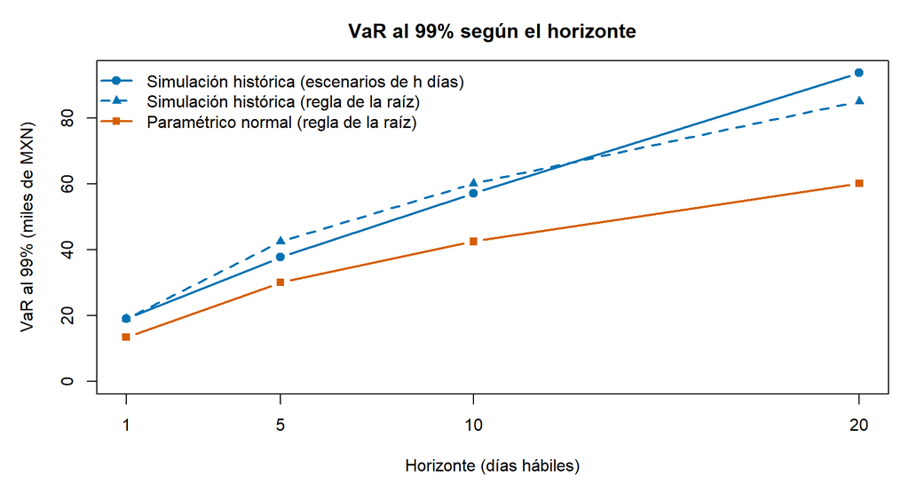

Figura 3. VaR al 99% del portafolio según el horizonte: simulación histórica con escenarios de h días, simulación histórica con la regla de la raíz y VaR paramétrico normal.

A diez días, el VaR paramétrico al 99% es de **$42,516** (7.09% de V<sub>0</sub>) y a veinte días de $60,126 (Tabla 17). En los cuatro horizontes el VaR paramétrico es menor que el histórico al 99% (Figura 3); la sección 8 descompone esa diferencia.

# 5 Backtesting

## 5.1 Diseño fuera de muestra

El *backtesting* compara el VaR pronosticado con la pérdida que realmente ocurrió. Atendiendo la retroalimentación de la Parte 4, lo diseñamos para que la validación sea **independiente** de la estimación. Evaluamos los últimos 500 días hábiles, del 27 de noviembre de 2024 al 26 de noviembre de 2026, el mismo número de días de prueba del código de clase. Para cada día $t$ de ese periodo:

1. El VaR se calcula al cierre del día anterior, **sólo con la información disponible hasta $t-1$**. Ningún dato del día $t$ ni posterior interviene en su propio pronóstico; las ventanas se mueven un día a la vez (*walk-forward*).
2. **Simulación histórica:** usa toda la información disponible hasta $t-1$, exactamente el método de la sección 3 (la ventana crece con el tiempo). Como contraste, también evaluamos la ventana móvil de 500 días del código de clase.
3. **Paramétrico:** $\sigma_p$ se recalcula cada día con los 129 rendimientos previos (seis meses), como en la sección 4.
4. La pérdida observada es la del portafolio de 100 mil pesos por emisora, $P\&L_t=\sum_j 100{,}000\left(e^{r_{j,t}}-1\right)$. El portafolio se rebalancea cada día a la composición de la consigna, de modo que se evalúa exactamente el portafolio analizado y su composición no usa información posterior a $t$.
5. Hay una **violación** cuando $P\&L_t<-VaR_t$. Con 500 días se esperan 25 violaciones al 95%, 12.5 al 97.5% y 5 al 99%.

Para evaluar las violaciones usamos tres pruebas. La de **Kupiec** (1995) contrasta si la frecuencia de violaciones $\hat\pi=x/T$ es igual a la teórica $p=1-c$:

$$LR_{POF}=-2\ln\left[(1-p)^{T-x}p^{x}\right]+2\ln\left[(1-\hat\pi)^{T-x}\hat\pi^{x}\right]\sim\chi^2_1
.$$

La de **independencia de Christoffersen** (1998) contrasta si una violación hoy hace más probable otra mañana; con $\pi_{ij}$ la probabilidad de pasar del estado $i$ al $j$ (1 = violación),

$$LR_{ind}=-2\ln\left[(1-\hat\pi)^{n_{00}+n_{10}}\hat\pi^{\,n_{01}+n_{11}}\right]+2\ln\left[(1-\hat\pi_{01})^{n_{00}}\hat\pi_{01}^{\,n_{01}}(1-\hat\pi_{11})^{n_{10}}\hat\pi_{11}^{\,n_{11}}\right]\sim\chi^2_1,$$

y la de **cobertura condicional** las combina, $LR_{cc}=LR_{POF}+LR_{ind}\sim\chi^2_2$. Por último, el **semáforo de Basilea** clasifica las excepciones de los últimos 250 días al 99%: zona verde de 0 a 4, amarilla de 5 a 9 (el multiplicador de capital sube de 3 a entre 3.40 y 3.85) y roja de 10 o más (multiplicador de 4) (Basel Committee on Banking Supervision, 1996).

## 5.2 Resultados

Tabla 18. Backtesting del VaR a un día, 27 de noviembre de 2024 a 26 de noviembre de 2026 (500 días fuera de muestra)

| Método | Nivel | Esperadas | Observadas | Tasa (%) | Kupiec LR | Kupiec p | Independencia p | Cobertura condicional p | VaR promedio (MXN) |
| --- | --- | --- | --- | --- | --- | --- | --- | --- | --- |
| Simulación histórica (toda la información) | 95% | 25.0 | 20 | 4.00 | 1.13 | 0.288 | 0.234 | 0.280 | 10,777 |
| Simulación histórica (toda la información) | 97.5% | 12.5 | 7 | 1.40 | 2.94 | 0.086 | 0.655 | 0.208 | 13,865 |
| Simulación histórica (toda la información) | 99% | 5.0 | 3 | 0.60 | 0.94 | 0.331 | 0.849 | 0.613 | 20,258 |
| Simulación histórica (ventana móvil de 500 días) | 95% | 25.0 | 23 | 4.60 | 0.17 | 0.678 | 0.099 | 0.235 | 10,434 |
| Simulación histórica (ventana móvil de 500 días) | 97.5% | 12.5 | 14 | 2.80 | 0.18 | 0.673 | 0.399 | 0.641 | 12,571 |
| Simulación histórica (ventana móvil de 500 días) | 99% | 5.0 | 7 | 1.40 | 0.72 | 0.397 | 0.655 | 0.632 | 16,293 |
| Paramétrico normal (seis meses) | 95% | 25.0 | 20 | 4.00 | 1.13 | 0.288 | 0.006 | 0.013 | 11,461 |
| Paramétrico normal (seis meses) | 97.5% | 12.5 | 13 | 2.60 | 0.02 | 0.887 | 0.339 | 0.627 | 13,657 |
| Paramétrico normal (seis meses) | 99% | 5.0 | 5 | 1.00 | 0.00 | 1.000 | 0.750 | 0.951 | 16,210 |

Tabla 19. Semáforo de Basilea (últimos 250 días de prueba) y severidad de las violaciones del VaR al 99%

| Método | Excepciones (250 días, 99%) | Prob. acumulada binomial (%) | Zona | Multiplicador de capital | Pérdida media en violaciones (MXN) | VaR medio en esos días (MXN) | ES 99% pronosticado en esos días (MXN) |
| --- | --- | --- | --- | --- | --- | --- | --- |
| Simulación histórica (toda la información) | 1 | 28.58 | Verde | 3.00 | 27,220 | 20,156 | 28,628 |
| Simulación histórica (ventana móvil de 500 días) | 3 | 75.81 | Verde | 3.00 | — | — | — |
| Paramétrico normal (seis meses) | 2 | 54.32 | Verde | 3.00 | 23,247 | 15,211 | 17,427 |

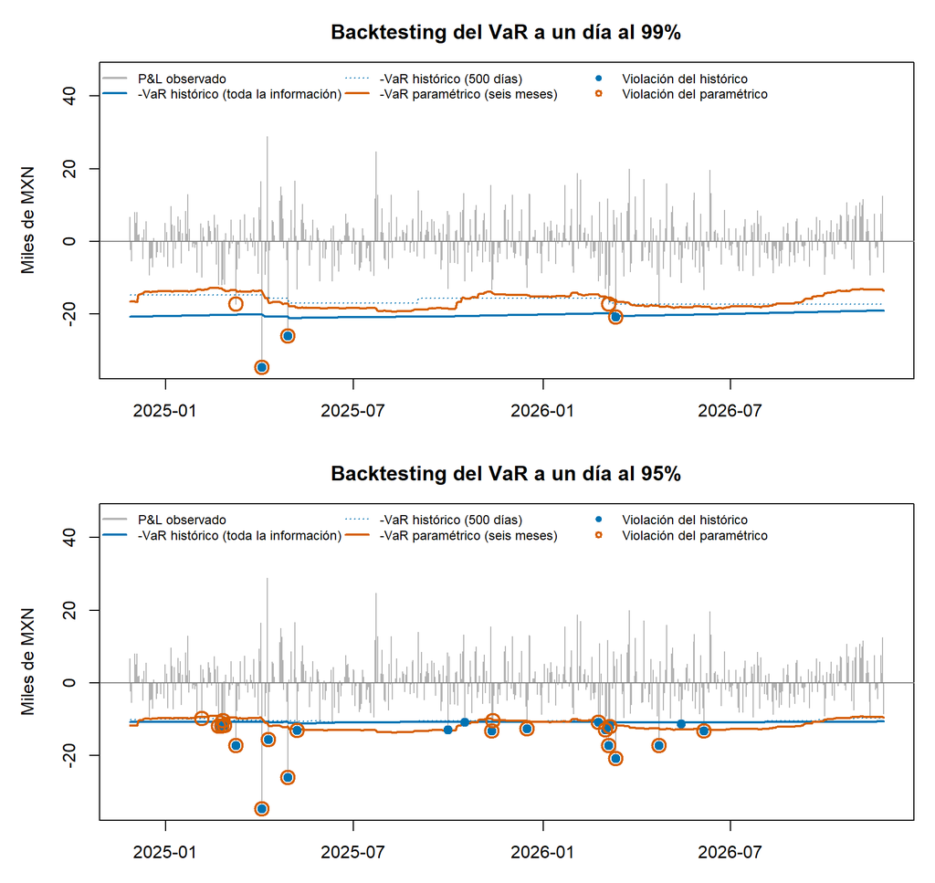

Figura 4. Backtesting del VaR a un día al 99% (arriba) y al 95% (abajo). Las barras son la P&L observada del portafolio; las líneas, el VaR pronosticado con información hasta el día anterior; los puntos, las violaciones.

**Simulación histórica (toda la información).** Al 99%, 3 violaciones frente a 5.0 esperadas (0.60%; Kupiec p = 0.331), por lo que no se rechaza la cobertura correcta. Al 95%, 20 violaciones frente a 25.0 esperadas (4.00%; Kupiec p = 0.288), de modo que no se rechaza la cobertura correcta.

**VaR paramétrico (seis meses).** Al 99%, 5 violaciones frente a 5.0 esperadas (1.00%; Kupiec p = 1.000), por lo que no se rechaza la cobertura correcta. Al 95%, 20 violaciones frente a 25.0 esperadas (4.00%; Kupiec p = 0.288), de modo que no se rechaza la cobertura correcta.

**Dependencia y severidad.** La independencia de Christoffersen se rechaza al 5% en 1 caso (Tabla 18): ahí las violaciones llegan en rachas, la señal típica de un modelo que reacciona tarde a un aumento de volatilidad. En los últimos 250 días, la simulación histórica queda en zona **verde** con 1 excepción y el paramétrico en zona **verde** con 2 (Tabla 19). Cuando el VaR paramétrico al 99% falló, la pérdida promedio fue de $23,247, 1.53 veces el VaR de esos días; en la simulación histórica fue de $27,220, 1.35 veces su VaR. El ES pronosticado en esos días permite juzgar si el modelo anticipa la magnitud de las pérdidas extremas y no sólo su frecuencia.

**Ventana móvil de 500 días.** Con la ventana del código de clase, la simulación histórica registra al 99% 7 violaciones frente a 5.0 esperadas (1.40%; Kupiec p = 0.397). Tiene más violaciones que la versión con toda la información porque su ventana ya no contiene la crisis de 2020 y su cola izquierda es más corta: es el costo de olvidar episodios de estrés.

**¿Qué modelo tiene mejor desempeño?** Fijamos la regla antes de ver los resultados. Primero cuenta el número de pruebas superadas al 5% (Kupiec y cobertura condicional en los tres niveles, un máximo de 6); en caso de empate, la cercanía a la frecuencia teórica; y después, el VaR promedio más bajo, porque a igual cobertura el modelo más preciso inmoviliza menos capital. Con esa regla, el modelo con mejor desempeño es **la simulación histórica**, que supera 6 de 6 pruebas, frente a 5 del VaR paramétrico. El VaR paramétrico fue mayor que el histórico en 0.0% de los días de prueba: su nivel sube y baja con la volatilidad reciente, mientras que el histórico con toda la información cambia muy poco de un día a otro.

# 6 Optimización del portafolio

## 6.1 Planteamiento

Con $V_0$ y $c$ fijos y media cero, $VaR_{p,c}=z_cV_0\sqrt{w^{\top}\Sigma w}$. Como $z_cV_0>0$ y la raíz es creciente, minimizar el VaR equivale a minimizar la varianza del portafolio, el problema clásico de Markowitz (1952) aplicado al riesgo de pérdida (Ruiz, 2026b):

$$\min_{w}\; w^{\top}\Sigma\,w\qquad
\text{s.a.}\qquad \mathbf{1}^{\top}w=1,\qquad w_j\ge 0 .$$

Sin ventas en corto no hay solución cerrada, así que resolvemos el problema cuadrático con `solve.QP` del paquete `quadprog` (Turlach y Weingessel, 2019), igual que en el código de clase: $D=2\Sigma$, $d=0$ y restricciones $A^{\top}w\ge b$ con la primera como igualdad. Usamos la matriz $\Sigma$ de los últimos seis meses para minimizar el mismo VaR paramétrico de la sección 4. Como complemento, buscamos numéricamente los pesos que minimizan el VaR histórico al 99% (Nelder-Mead sobre pesos positivos que suman uno). Esta búsqueda se hace dentro de la muestra y se ajusta a unos cuantos escenarios de la cola, por lo que la reportamos sólo como referencia.

## 6.2 Composición óptima y comparación con el portafolio inicial

Tabla 20. Composición del portafolio inicial y de VaR mínimo (V0 = 600 mil pesos)

| Emisora | Inicial (%) | VaR mínimo (%) | VaR mínimo (MXN) | Acciones (VaR mínimo) | Con Σ de toda la muestra (%) | VaR histórico mínimo (%) |
| --- | --- | --- | --- | --- | --- | --- |
| GFNORTE | 16.67 | 2.08 | 12,504 | 61.56 | 3.36 | 1.43 |
| BIMBO | 16.67 | 12.70 | 76,226 | 1,061.94 | 16.33 | 19.93 |
| WALMEX | 16.67 | 28.06 | 168,353 | 3,120.54 | 27.46 | 36.27 |
| AMX | 16.67 | 17.92 | 107,528 | 4,426.84 | 36.21 | 25.34 |
| VOLAR | 16.67 | 3.77 | 22,601 | 1,402.03 | 3.39 | 2.46 |
| BBAJIO | 16.67 | 35.46 | 212,788 | 3,814.09 | 13.24 | 14.58 |
| Total | 100.00 | 100.00 | 600,000 | — | 100.00 | 100.00 |

Tabla 21. Riesgo y diversificación del portafolio inicial y de los portafolios optimizados

| Medida | Inicial | VaR paramétrico mínimo | VaR histórico mínimo (referencia) |
| --- | --- | --- | --- |
| VaR paramétrico 99%, un día (MXN) | 13,445 | 11,665 | 12,740 |
| ES paramétrico 99% (MXN) | 15,403 | 13,364 | 14,595 |
| VaR histórico 99%, un día (MXN) | 19,022 | 18,541 | 14,493 |
| ES histórico 99% (MXN) | 27,809 | 23,987 | 21,228 |
| Volatilidad anual (seis meses) | 15.29% | 13.27% | 14.49% |
| Número efectivo de emisoras (1/Σw²) | 6.00 | 3.93 | 3.88 |
| Razón de diversificación (Σwσ / σp) | 1.78 | 1.78 | 1.66 |
| Beneficio de diversificación 99% (MXN) | 10,452 | 9,153 | 8,379 |
| Mayor contribución individual al riesgo | 32.1% | 35.5% | 39.3% |
| Emisoras con peso mayor a 0.5% | 6 | 6 | 6 |

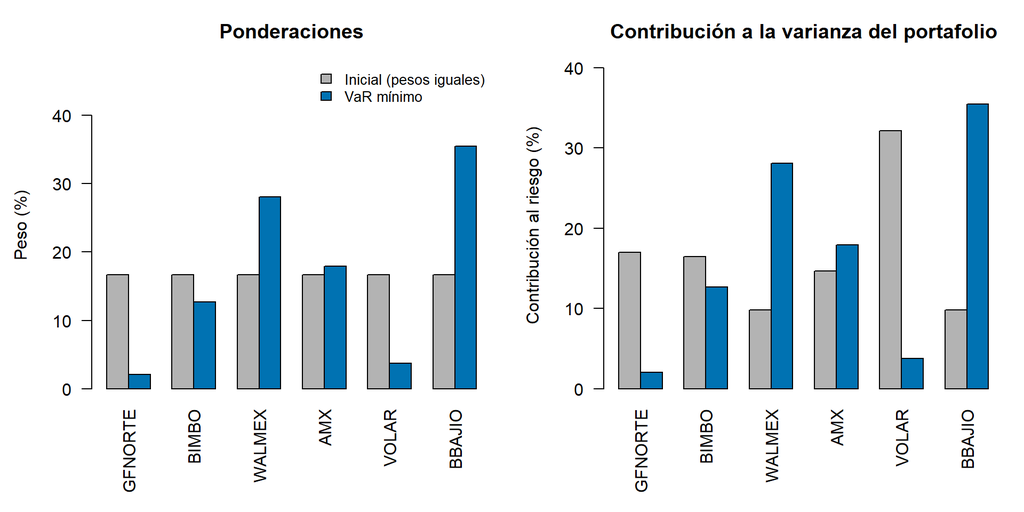

Figura 5. Ponderaciones (izquierda) y contribución de cada emisora a la varianza del portafolio (derecha): portafolio inicial frente al de VaR mínimo.

El portafolio de VaR mínimo concentra la inversión en BBAJIO (35.5%), WALMEX (28.1%) y AMX (17.9%) (Tabla 20). El optimizador no elige sólo las emisoras menos volátiles: favorece las que, además, tienen baja correlación con el resto, porque lo que se minimiza es la varianza conjunta (Ruiz, 2026b). El VaR paramétrico al 99% baja de $13,445 a **$11,665**, una reducción de 13.2% con la misma inversión, y el VaR histórico al 99% de esa misma composición baja 2.5%, lo que confirma que la reducción no depende del supuesto normal (Tabla 21).

**Efecto sobre la diversificación.** Hay que distinguir dos ideas. Medida por el número de emisoras, la diversificación disminuye: el número efectivo de emisoras pasa de 6.00 a 3.93. Medida por su efecto sobre el riesgo, aumenta: la razón de diversificación (volatilidad promedio ponderada entre volatilidad del portafolio) pasa de 1.78 a 1.78. En el portafolio inicial VOLAR aportaba 32.1% del riesgo con 16.7% del capital. En el óptimo, la mayor contribución individual es de 35.5% y las contribuciones de las emisoras incluidas son proporcionales a sus pesos (Figura 5): en la varianza mínima todas tienen el mismo riesgo marginal.

**Riesgo de estimación.** Con la matriz de covarianzas de toda la muestra, los pesos óptimos cambian en 23.2% del portafolio (la mitad de la suma de las diferencias absolutas; Tabla 20). Es un cambio grande: la composición óptima es sensible a la ventana de estimación, una limitación conocida de la optimización de media-varianza que obliga a revisarla periódicamente. La composición que minimiza el VaR histórico dentro de la muestra lleva ese VaR a $14,493, pero se ajusta a unos 20 escenarios de la cola y no debe tomarse como recomendación.

## 6.3 ¿Se sostiene la reducción fuera de muestra?

Para no evaluar la optimización con los mismos datos que la generaron, estimamos los pesos de varianza mínima con los seis meses previos al periodo de prueba (hasta el 26 de noviembre de 2024) y medimos el riesgo realizado de ambos portafolios en los 500 días siguientes.

Tabla 22. Verificación fuera de muestra de la optimización (27 de noviembre de 2024 a 26 de noviembre de 2026)

| Medida | Inicial (pesos iguales) | Varianza mínima (pesos estimados antes de la prueba) |
| --- | --- | --- |
| Volatilidad anual realizada | 18.48% | 18.64% |
| Pérdida en el percentil 1% realizado (MXN) | 17,249 | 14,064 |
| Peor pérdida diaria (MXN) | 34,653 | 28,672 |

Fuera de muestra, el portafolio de varianza mínima tuvo una volatilidad realizada 0.8% mayor que la del portafolio de pesos iguales (Tabla 22). La reducción estimada dentro de la muestra no se sostuvo, lo que ilustra el riesgo de estimación de la optimización. La lección para la toma de decisiones es que los pesos óptimos son una estimación, no un dato, y deben revisarse conforme cambian las volatilidades y correlaciones.

# 7 VaR individual de BanBajío por simulación Montecarlo

## 7.1 Metodología

Estimamos el VaR y el ES al 99% a un día de una posición de 100 mil pesos en BanBajío (1,792.44 acciones a $55.79), con la simulación Montecarlo del código de clase. El precio de mañana se simula con el movimiento browniano geométrico (Ruiz, 2026c):

$$S_1^{(i)}=S_0\exp\left[\left(\mu-\frac{\sigma^2}{2}\right)\Delta
t+\sigma\sqrt{\Delta t}\,Z^{(i)}\right],\qquad Z^{(i)}\sim N(0,1),\qquad
P\&L^{(i)}=n\left(S_1^{(i)}-S_0\right),$$

con $\Delta t=1$ día, $\mu=\bar r+\sigma^2/2$ y $\sigma$ estimados con toda la muestra de rendimientos diarios de BBAJIO (los mismos datos de la simulación histórica), $N=10{,}000$ simulaciones y semilla 123 para que el resultado sea replicable. Entonces

$$VaR_{99\%}=-Q_{0.01}\left(P\&L^{MC}\right),\qquad
ES_{99\%}=-\frac{1}{\#\{i:\,P\&L^{(i)}<-VaR\}}\sum_{P\&L^{(i)}<-VaR}P\&L^{(i)}
.$$

La consigna ubica a Montecarlo entre las metodologías no paramétricas porque el VaR sale de un cuantil de escenarios y no de una fórmula. Como advierte la Unidad 05, cuando los choques se generan con una normal el método incorpora un supuesto paramétrico (Ruiz, 2026c). Por eso añadimos una versión **por remuestreo** (*bootstrap*; Efron, 1979): los 10,000 choques se extraen con reemplazo de los rendimientos históricos de BBAJIO y no suponen ninguna distribución.

Tabla 23. Parámetros de la simulación Montecarlo de BBAJIO (toda la muestra)

| Parámetro | Valor |
| --- | --- |
| Precio inicial S0 (MXN) | 55.79 |
| Acciones | 1,792.44 |
| Valor de la posición (MXN) | 100,000 |
| Rendimiento log. medio diario | 0.0508% |
| Volatilidad diaria | 2.041% |
| Deriva del GBM, μ | 0.0717% |
| Curtosis de los rendimientos | 6.08 |
| Simulaciones (N) | 10,000 |
| Semilla | 123 |

## 7.2 Resultados

Tabla 24. VaR y ES al 99% a un día de una posición de 100 mil pesos en BBAJIO

| Método | VaR 99% (MXN) | VaR 99% (% de la posición) | ES 99% (MXN) | ES 99% (% de la posición) |
| --- | --- | --- | --- | --- |
| Montecarlo con GBM (choques normales) | 4,574 | 4.57 | 5,197 | 5.20 |
| Montecarlo por remuestreo (choques empíricos) | 5,611 | 5.61 | 7,549 | 7.55 |
| Simulación histórica (toda la muestra) | 5,479 | 5.48 | 7,215 | 7.22 |
| Paramétrico normal (volatilidad de seis meses) | 3,116 | 3.12 | 3,569 | 3.57 |
| Paramétrico normal (volatilidad de toda la muestra) | 4,748 | 4.75 | 5,440 | 5.44 |

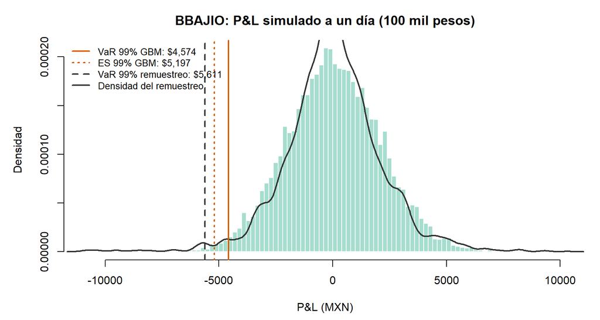

Figura 6. Distribución simulada de pérdidas y ganancias a un día de la posición de 100 mil pesos en BBAJIO: Montecarlo con GBM (histograma) y Montecarlo por remuestreo (línea). Las líneas verticales marcan el VaR y el ES al 99%.

Con 99% de confianza, la posición de 100 mil pesos en BanBajío no debería perder más de **$4,574** en un día, **4.57% de la posición**, según el Montecarlo con GBM. El intervalo de 95% del cuantil simulado va de $4,429 a $4,688, de modo que el error de simulación con 10,000 escenarios es pequeño. Cuando se rebasa el VaR, la pérdida esperada es el **ES al 99% de $5,197 (5.20% de la posición)**, con un error estándar de $58.

El remuestreo, que conserva la distribución empírica de BBAJIO (curtosis de 6.08), da un VaR al 99% de $5,611 y un ES de $7,549 (Tabla 24). Su ES es 45.3% mayor que el del GBM: la normal reproduce bien el centro de la distribución, pero subestima la magnitud de las pérdidas una vez rebasado el umbral. La simulación histórica da $5,479, consistente con el remuestreo porque ambos usan los mismos rendimientos observados. Con la volatilidad de los últimos seis meses, el VaR paramétrico sería de $3,116, menor que con toda la muestra porque el régimen reciente de BBAJIO es más tranquilo que su promedio. Como referencia, en la Parte 4 el promedio móvil de 60 días daba al 30 de octubre un VaR al 99% de 24,433 pesos por cada millón (2.44%). Las diferencias entre estas cifras provienen de la ventana y del supuesto de distribución, los dos mismos factores que separan al VaR histórico del paramétrico en el portafolio.

# 8 Análisis e interpretación

## 8.1 Comparación estructurada de las metodologías

Tabla 25. Comparación estructurada de las dos metodologías (portafolio de 600 mil pesos)

| Aspecto | Simulación histórica | Paramétrico normal |
| --- | --- | --- |
| Información que usa | Toda la muestra (1,987 días) | Últimos seis meses (129 días) |
| Supuesto de distribución | Ninguno: distribución empírica | Normal conjunta con media cero |
| Dependencia entre emisoras | Movimientos conjuntos observados | Matriz de covarianzas Σ |
| Escalamiento a h días | Escenarios históricos de h días | Regla de la raíz |
| VaR 99% a un día (MXN) | 19,022 | 13,445 |
| VaR 99% a 10 días (MXN) | 57,196 | 42,516 |
| ES 99% a un día (MXN) | 27,809 | 15,403 |
| ES / VaR al 99% | 1.46 | 1.15 |
| Violaciones al 99% (esperadas: 5) | 3 | 5 |
| Kupiec p al 99% | 0.331 | 1.000 |
| Zona de Basilea (250 días) | Verde | Verde |
| Principal fortaleza | Conserva colas pesadas y crisis reales | Simple, reacciona a la volatilidad reciente y permite optimizar |
| Principal limitación | No anticipa choques ausentes de la muestra; reacciona lento | Subestima la cola si los rendimientos no son normales |

Tabla 26. Descomposición de la diferencia entre el VaR histórico y el paramétrico a un día (MXN)

| Concepto | 95% | 97.5% | 99% |
| --- | --- | --- | --- |
| VaR paramétrico (seis meses) | 9,506 | 11,327 | 13,445 |
| Efecto de la ventana: seis meses → toda la muestra | 2,584 | 3,079 | 3,654 |
| VaR paramétrico (toda la muestra) | 12,090 | 14,406 | 17,099 |
| Efecto de la distribución: normal → empírica | -1,483 | -1,084 | 1,923 |
| VaR histórico (toda la muestra) | 10,607 | 13,322 | 19,022 |
| Diferencia total (histórico − paramétrico) | 1,101 | 1,995 | 5,577 |

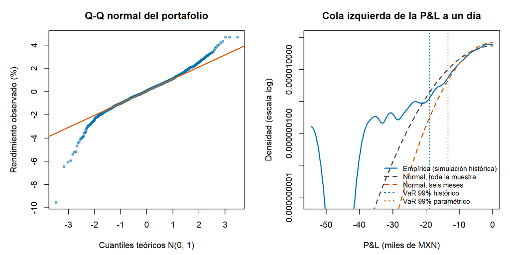

Figura 7. Izquierda: gráfica cuantil-cuantil de los rendimientos diarios del portafolio frente a la normal. Derecha: densidad de la cola izquierda de la P&L (escala logarítmica), empírica frente a las normales con la volatilidad de toda la muestra y de seis meses; las líneas verticales marcan el VaR al 99% de cada método.

## 8.2 ¿Qué diferencias observan entre el VaR paramétrico y no paramétrico?

A un día y al 99%, el VaR histórico es de $19,022 y el paramétrico de $13,445: el histórico es 1.41 veces el paramétrico. Al 95% la razón es de 1.12 (Tablas 8 y 16). La diferencia no es aleatoria; tiene dos fuentes que pueden separarse (Tabla 26):

1. **La ventana.** Pasar de los últimos seis meses a toda la muestra, manteniendo la normal, eleva el VaR al 99% en $3,654. Que el VaR suba indica que la volatilidad reciente es menor que la histórica: el paramétrico mide un mercado tranquilo, mientras que la simulación histórica recuerda también los episodios de estrés.
2. **La distribución.** Con la misma ventana (toda la muestra), pasar de la normal a la distribución empírica eleva el VaR al 99% en $1,923, mientras que al 95% lo reduce en $1,483. Que el efecto crezca al alejarse en la cola es la huella de las colas pesadas: la normal acierta en el centro de la distribución, pero asigna muy poca probabilidad a las pérdidas extremas.

Hay además una diferencia de método en los horizontes largos. El paramétrico escala con $\sqrt{h}$, mientras que el histórico usa escenarios reales de $h$ días, que a 20 días quedan por encima de la raíz (Tabla 10). Y hay una diferencia de comportamiento: el paramétrico de seis meses sube y baja con la volatilidad reciente, mientras que el histórico con toda la información es casi constante (Figura 4).

## 8.3 ¿Cuál modelo captura mejor los eventos extremos?

La **simulación histórica**, por construcción. Los rendimientos del portafolio tienen curtosis de 6.94, y la gráfica cuantil-cuantil se separa de la recta en las colas (Figura 7). En toda la muestra hubo 27 días (1.36%) con pérdidas mayores que el VaR normal al 99% calculado con la volatilidad de toda la muestra, frente al 1% que supone la normal; la peor pérdida equivale a 7.4 desviaciones estándar: bajo normalidad, una pérdida de ese tamaño ocurriría en promedio una vez cada más de un millón de años de operación. En la cola izquierda la densidad empírica queda por encima de las normales (Figura 7, derecha). El ES lo resume: en el histórico el ES al 99% es 1.46 veces el VaR, frente a 1.15 en la normal, así que una vez rebasado el umbral la pérdida promedio es mayor de lo que anticipa el modelo paramétrico. Lo mismo se observa en BanBajío: el remuestreo da un ES de $7,549 frente a $5,197 del Montecarlo normal (Tabla 24).

Hay dos matices. Primero, la simulación histórica sólo captura los extremos **que ya ocurrieron** en la ventana: si se excluyera 2020, el VaR al 99% bajaría de $19,022 a $15,879 (Tabla 11), y ningún método histórico anticipa un choque sin precedente. Segundo, el paramétrico reacciona más rápido cuando la volatilidad sube, de modo que en un episodio nuevo de estrés puede superar temporalmente al histórico. La herramienta para los extremos sin precedente son las pruebas de estrés, no el VaR.

## 8.4 ¿Qué modelo es más conservador?

En la fecha de análisis el más conservador es **la simulación histórica**, con un VaR al 99% de $19,022 frente a $13,445. En el periodo de prueba, el VaR paramétrico fue mayor que el histórico en 0.0% de los días, y la simulación histórica tuvo 3 violaciones al 99% frente a 5 del paramétrico (Tabla 18). Ser conservador no equivale a ser mejor: un VaR sistemáticamente alto tiene menos violaciones de las esperadas, inmoviliza capital que podría invertirse y, si es excesivo, también lo rechaza la prueba de Kupiec. Lo deseable es un VaR que falle con la frecuencia que promete.

## 8.5 ¿Qué implicaciones tiene elegir un modelo que subestima el riesgo?

Un VaR que subestima el riesgo da una falsa sensación de seguridad justo cuando más importa:

- **Capital insuficiente.** Las pérdidas extremas consumen un colchón que se calculó demasiado pequeño, y la institución puede verse obligada a vender en el peor momento, lo que amplifica la pérdida.
- **Límites demasiado holgados.** Los límites de exposición y las posiciones se dimensionan con el VaR, así que un VaR bajo permite tomar más riesgo del que la institución está dispuesta a asumir.
- **Penalización regulatoria.** Bajo Basilea, cada excepción adicional en 250 días aumenta el multiplicador del capital por riesgo de mercado. Con los resultados de la Tabla 19, el multiplicador sería de 3.00 para la simulación histórica y de 3.00 para el paramétrico. Aplicado al VaR a diez días de hoy, el capital ilustrativo sería de $171,587 y $127,547, respectivamente. Un modelo que subestima recibe un multiplicador mayor y pierde credibilidad ante el supervisor.
- **Decisiones de portafolio sesgadas.** Si el modelo ignora las colas pesadas, la optimización favorece activos que parecen seguros por su volatilidad, pero que pueden tener caídas abruptas.

Para un banco como BanBajío, cuyo negocio depende de la confianza y de cumplir requerimientos de capital, subestimar el riesgo es más costoso que sobreestimarlo: el costo de un VaR alto es capital ocioso, mientras que el de un VaR bajo puede ser una pérdida que comprometa la solvencia.

## 8.6 ¿Qué resultados arroja el backtesting y qué concluyen de ello?

En 500 días fuera de muestra, la simulación histórica con toda la información registró al 99% 3 violaciones frente a 5.0 esperadas (0.60%; Kupiec p = 0.331) y el paramétrico 5 violaciones frente a 5.0 esperadas (1.00%; Kupiec p = 1.000). Al 95%, la simulación histórica tuvo 20 violaciones frente a 25.0 esperadas (4.00%; Kupiec p = 0.288) y el paramétrico 20 violaciones frente a 25.0 esperadas (4.00%; Kupiec p = 0.288) (Tabla 18). En los últimos 250 días quedan en zona verde y verde, respectivamente (Tabla 19). Con la regla de decisión definida antes de ver los resultados, el modelo con mejor desempeño es **la simulación histórica**.

Concluimos tres cosas. Primero, el *backtesting* debe ser fuera de muestra: comparar el VaR con las mismas pérdidas que lo generaron mide ajuste, no capacidad de pronóstico, la distinción que señaló la retroalimentación de la Parte 4. Segundo, contar violaciones no basta. También importa si llegan en rachas (independencia) y qué tan grandes son cuando ocurren (severidad frente al ES). Tercero, con 500 días y un VaR al 99% se esperan apenas 5 violaciones, por lo que las pruebas tienen poca potencia; los resultados al 95% y 97.5% complementan la evaluación.

# 9 Conclusiones

## 9.1 Comparación de ambas metodologías

Las dos metodologías responden la misma pregunta, el cuantil de la cola izquierda de la P&L, pero construyen la distribución de forma distinta. La **simulación histórica** no impone un supuesto de distribución, conserva las colas pesadas y la dependencia observada entre las seis emisoras, e incorpora crisis reales como la de 2020; su precio es que depende de la ventana, no anticipa choques inéditos y reacciona lentamente cuando cambia el régimen de volatilidad. El **VaR paramétrico** es transparente, se calcula con pocas entradas ($\sigma$, $\Sigma$ y $z_c$), reacciona a la volatilidad reciente y permite optimizar analíticamente la composición; su precio es el supuesto normal, que subestima la cola cuando la curtosis es alta, y la regla $\sqrt{h}$, que supone independencia y volatilidad constante.

Tabla 27. Resumen de resultados al 26 de noviembre de 2026

| Resultado | Valor |
| --- | --- |
| Valor inicial del portafolio (V0) | $600,000 |
| VaR 99% a un día: simulación histórica | $19,022 |
| VaR 99% a un día: paramétrico | $13,445 |
| VaR 99% a 10 días: simulación histórica | $57,196 |
| VaR 99% a 10 días: paramétrico | $42,516 |
| ES 99% a un día: simulación histórica | $27,809 |
| ES 99% a un día: paramétrico | $15,403 |
| VaR 99% a un día del portafolio de VaR mínimo (paramétrico) | $11,665 |
| VaR 99% de 100 mil pesos en BBAJIO (Montecarlo) | $4,574 (4.57%) |
| ES 99% de 100 mil pesos en BBAJIO (Montecarlo) | $5,197 (5.20%) |
| Mejor desempeño en el backtesting | Simulación histórica (toda la información) |

## 9.2 Metodología que usaríamos en la práctica

Usaríamos **la simulación histórica con toda la información disponible como medida principal del VaR y del ES** del portafolio, y el VaR paramétrico como herramienta complementaria. La elección es coherente con el *backtesting*, en el que la simulación histórica tuvo el mejor desempeño fuera de muestra: al 99% registró 3 violaciones frente a 5.0 esperadas (0.60%; Kupiec p = 0.331). Además, se apoya en tres razones:

1. **Refleja el riesgo que importa.** Los rendimientos del portafolio tienen colas más pesadas que la normal (curtosis de 6.94), igual que los de BanBajío en la Parte 3, y la cola es exactamente lo que el VaR y el ES deben medir; la simulación histórica la reproduce sin suponer normalidad.
2. **Incorpora la dependencia en crisis.** En los días de estrés las correlaciones suben, y los escenarios conjuntos observados capturan ese efecto mejor que una matriz de covarianzas promedio.
3. **Usa toda la información y es auditable.** Cada escenario corresponde a una fecha real, lo que facilita explicarlo a un comité de riesgos o a un supervisor.

El VaR paramétrico de seis meses es valioso como **indicador de alerta temprana**, porque reacciona antes cuando sube la volatilidad, y como base de la **optimización** del portafolio, aunque la composición debe revisarse con frecuencia, porque la reducción de riesgo no se sostuvo fuera de muestra (sección 6). Lo ideal es reportar ambos junto con el ES y vigilar la diferencia entre ellos: si el paramétrico supera al histórico, el mercado entró en un régimen más volátil que el de la muestra.

## 9.3 Limitaciones y siguientes pasos

Los resultados deben leerse con cuatro precauciones. Primero, la simulación histórica depende de la ventana y no puede generar choques inéditos, por lo que conviene complementarla con pruebas de estrés. Segundo, con 500 días de prueba las pruebas de *backtesting* al 99% tienen poca potencia. Tercero, la composición de VaR mínimo depende de la matriz de covarianzas estimada y debe revisarse periódicamente. Cuarto, el Montecarlo con GBM hereda el supuesto normal; el remuestreo lo corrige sólo dentro de la experiencia histórica. Como siguiente paso proponemos una **simulación histórica filtrada**, que reescale los escenarios históricos con la volatilidad actual estimada con los modelos EWMA o GARCH de la Parte 4. Esa variante combina las colas empíricas de la simulación histórica con la capacidad de reacción del enfoque paramétrico.

# Referencias

Basel Committee on Banking Supervision. (1996). *Supervisory framework for the use of “backtesting” in conjunction with the internal models approach to market risk capital requirements*. Bank for International Settlements.

Basel Committee on Banking Supervision. (2019). *Minimum capital requirements for market risk*. Bank for International Settlements.

Christoffersen, P. F. (1998). Evaluating interval forecasts. *International Economic Review, 39*(4), 841–862.

Efron, B. (1979). Bootstrap methods: Another look at the jackknife. *The Annals of Statistics, 7*(1), 1–26.

Hull, J. C. (2018). *Options, futures, and other derivatives* (10.ª ed.). Pearson.

Hyndman, R. J., & Fan, Y. (1996). Sample quantiles in statistical packages. *The American Statistician, 50*(4), 361–365.

Jorion, P. (2007). *Value at risk: The new benchmark for managing financial risk* (3.ª ed.). McGraw-Hill.

Kupiec, P. H. (1995). Techniques for verifying the accuracy of risk measurement models. *The Journal of Derivatives, 3*(2), 73–84.

Markowitz, H. (1952). Portfolio selection. *The Journal of Finance, 7*(1), 77–91.

R Core Team. (2026). *R: A language and environment for statistical computing* (versión 4.6.1). R Foundation for Statistical Computing. https://www.R-project.org/

Rojas Alvarado, J., Hernández Soto, A. J., Ramírez Avila, F. J., & Mendez, J. P. (2026). *Proyecto Final, Partes 1 a 4: Banco del Bajío*. Análisis del Riesgo, ITESO.

Ruiz, R. (2026a). *¿Qué mide realmente el valor en riesgo (VaR)?* [Presentación de clase, Unidad 04]. Análisis del Riesgo, ITESO.

Ruiz, R. (2026b). *VaR de acciones y carteras* [Presentación de clase, Unidad 04]. Análisis del Riesgo, ITESO.

Ruiz, R. (2026c). *VaR de portafolios de acciones por simulación: histórica y Monte Carlo* [Presentación de clase, Unidad 05]. Análisis del Riesgo, ITESO.

Ruiz, R. (2026d). *Códigos de clase: VaR paramétrico de acciones, VaR no paramétrico de portafolios y transición a mínima varianza* [Archivos de R]. Análisis del Riesgo, ITESO.

Ryan, J. A., & Ulrich, J. M. (2026). *quantmod: Quantitative financial modelling framework* (versión 0.4.29) [Paquete de R]. https://CRAN.R-project.org/package=quantmod

Turlach, B. A., & Weingessel, A. (2019). *quadprog: Functions to solve quadratic programming problems* (versión 1.5.8) [Paquete de R]. https://CRAN.R-project.org/package=quadprog

Yahoo Finance. (2026). *Datos históricos de GFNORTEO.MX, BIMBOA.MX, WALMEX.MX, AMXB.MX, VOLARA.MX y BBAJIOO.MX*. https://finance.yahoo.com/